# Iterate crawling and downloading files

John Little

2022-07-11

This lesson will show how to use the `rvest` package to facilitate web crawling for data. Below you will see an abridged presentation based on a longer [workshop on web crawling](https://rfun.library.duke.edu/portfolio/scraping_workshop/). The downloaded data are excel workbook files, each containing approximately 50 worksheets. Although some likely next steps could include iterating over worksheets within each workbook, I will stop short of presenting further [data wrangling techniques for concatenating readxl workflows](https://readxl.tidyverse.org/articles/readxl-workflows.html). Additionally, because the files are voluminous, at the end of this script I include a function to delete the downloaded workbook files.

That advanced worksheet wrangling can be gleaned by reading an excellent article on *readxl workflows*, particularly but not limited to the section *concatenate worksheets into one data frame*.

```r
library(tidyverse)
library(readxl)
library(fs)
library(rvest)
```

## Data

The data we will scrape is from the [US Census pulse survey](https://www.census.gov/newsroom/press-kits/2020/pulse-surveys.html). Sepcifically we will look at the data from the [pulse surveys household experience](https://www.census.gov/data/experimental-data-products/household-pulse-survey.html)

The target household data is outlined at this [summary navigation page](https://www.census.gov/programs-surveys/household-pulse-survey/data.html). [The weekly pulse surveys](https://www.census.gov/data/tables/2020/demo/hhp/hhp13.html) are linked here and each file has a different and somewhat unpredictable URL.

> We can use `rvest` to crawl the summary page and harvest the urls of target files. curl_download() to download each file into a target directory within the RStudio project on the local file system.

Here are some example files of the housing pulse survey file 2b  
- housing2b_se_week7.xlsx - housing2b_se_week13.xlsx - housing2b_week37.xlsx - housing2b_week45.xlsx

Assign some object names so I have an easy way to refer to my needed URLs. Use `read_html()` to ingest the raw HTML of the example page.

```r
my_url <- "https://www.census.gov/programs-surveys/household-pulse-survey/data.html"
base_url <- "https://www.census.gov/"

my_results <- read_html(my_url)
```

Crawl the target webpages to gather a list of URLs for files that may be download

```r
link_text <- my_results %>%
  html_nodes(".uscb-title-3") %>%
  html_text2()

link_url <- my_results %>%
  html_nodes("a.uscb-list-item") %>%
  html_attr("href")


my_crawl <- tibble(link_text, link_url, base_url) %>%
  filter(str_detect(link_text, "Household Pulse Survey:")) %>%
  unite(full_url, base_url, link_url, remove = TRUE, sep = "") %>%
  mutate(full_url = str_replace(full_url, 'gov//data', 'gov/data')) %>%
  relocate(full_url)
my_crawl
```

| full_url | link_text |
| --- | --- |
| https://www.census.gov/data/tables/2022/demo/hhp/hhp46.html | Week 46 Household Pulse Survey: June 1 - June 13 |
| https://www.census.gov/data/tables/2022/demo/hhp/hhp45.html | Week 45 Household Pulse Survey: April 27 - May 9, 2022 |
| https://www.census.gov/data/tables/2022/demo/hhp/hhp44.html | Week 44 Household Pulse Survey: March 30 – April 11 |
| https://www.census.gov/data/tables/2022/demo/hhp/hhp43.html | Week 43 Household Pulse Survey: March 2 – March 14 |
| https://www.census.gov/data/tables/2022/demo/hhp/hhp42.html | Week 42 Household Pulse Survey: January 26 – February 7 |
| https://www.census.gov/data/tables/2021/demo/hhp/hhp41.html | Week 41 Household Pulse Survey: December 29 – January 10 |
| https://www.census.gov/data/tables/2021/demo/hhp/hhp40.html | Week 40 Household Pulse Survey: December 1 – December 13 |
| https://www.census.gov/data/tables/2021/demo/hhp/hhp39.html | Week 39 Household Pulse Survey: September 29 – October 11 |
| https://www.census.gov/data/tables/2021/demo/hhp/hhp38.html | Week 38 Household Pulse Survey: September 15 – September 27 |
| https://www.census.gov/data/tables/2021/demo/hhp/hhp37.html | Week 37 Household Pulse Survey: September 1 – September 13 |

[output cut: 36 more lines]

Use `map()` with `nest()`, `Sys.sleep()` and `libary(rvest)` to gather the target URLs that will be downloaded.

```r
crawl_results <-
  my_crawl %>%
  slice(1:6) %>%
  # select(link_text_1, full_url) %>%
  nest(parenturl = -link_text) %>%
  mutate(my_rawhtml = map(parenturl, ~ {
    Sys.sleep(2)    ## DO THIS.  Pause 2 seconds between each file.  ##
    .x %>%
      pull(full_url) %>%
      read_html() %>%
      html_nodes("a") %>%
      html_attr("href") %>%
      tibble()
    }))
```

Subset the list of downloadable files to only the `housing2b` files.

```r
download_target_urls <- crawl_results %>%
  unnest(my_rawhtml) %>%
  rename(rawhtml = 3) %>%
  filter(str_detect(rawhtml, "housing2b")) %>%
  mutate(download_xworkbook_url = str_glue("https:{rawhtml}") ) %>%
  mutate(my_filename = fs::path_file(rawhtml))
download_target_urls
```

| link_text | parenturl | rawhtml | download_xworkbook_url | my_filename |
| --- | --- | --- | --- | --- |
| Week 45 Household Pulse Survey: April 27 - May 9, 2022 |  | //www2.census.gov/programs-surveys/demo/tables/hhp/2022/wk45/housing2b_week45.xlsx | https://www2.census.gov/programs-surveys/demo/tables/hhp/2022/wk45/housing2b_week45.xlsx | housing2b_week45.xlsx |
| Week 45 Household Pulse Survey: April 27 - May 9, 2022 |  | //www2.census.gov/programs-surveys/demo/tables/hhp/2022/wk45/housing2b_se_week45.xlsx | https://www2.census.gov/programs-surveys/demo/tables/hhp/2022/wk45/housing2b_se_week45.xlsx | housing2b_se_week45.xlsx |
| Week 44 Household Pulse Survey: March 30 – April 11 |  | //www2.census.gov/programs-surveys/demo/tables/hhp/2022/wk44/housing2b_week44.xlsx | https://www2.census.gov/programs-surveys/demo/tables/hhp/2022/wk44/housing2b_week44.xlsx | housing2b_week44.xlsx |
| Week 44 Household Pulse Survey: March 30 – April 11 |  | //www2.census.gov/programs-surveys/demo/tables/hhp/2022/wk44/housing2b_se_week44.xlsx | https://www2.census.gov/programs-surveys/demo/tables/hhp/2022/wk44/housing2b_se_week44.xlsx | housing2b_se_week44.xlsx |
| Week 43 Household Pulse Survey: March 2 – March 14 |  | //www2.census.gov/programs-surveys/demo/tables/hhp/2022/wk43/housing2b_week43.xlsx | https://www2.census.gov/programs-surveys/demo/tables/hhp/2022/wk43/housing2b_week43.xlsx | housing2b_week43.xlsx |
| Week 43 Household Pulse Survey: March 2 – March 14 |  | //www2.census.gov/programs-surveys/demo/tables/hhp/2022/wk43/housing2b_se_week43.xlsx | https://www2.census.gov/programs-surveys/demo/tables/hhp/2022/wk43/housing2b_se_week43.xlsx | housing2b_se_week43.xlsx |
| Week 42 Household Pulse Survey: January 26 – February 7 |  | //www2.census.gov/programs-surveys/demo/tables/hhp/2022/wk42/housing2b_week42.xlsx | https://www2.census.gov/programs-surveys/demo/tables/hhp/2022/wk42/housing2b_week42.xlsx | housing2b_week42.xlsx |
| Week 42 Household Pulse Survey: January 26 – February 7 |  | //www2.census.gov/programs-surveys/demo/tables/hhp/2022/wk42/housing2b_se_week42.xlsx | https://www2.census.gov/programs-surveys/demo/tables/hhp/2022/wk42/housing2b_se_week42.xlsx | housing2b_se_week42.xlsx |
| Week 41 Household Pulse Survey: December 29 – January 10 |  | //www2.census.gov/programs-surveys/demo/tables/hhp/2021/wk41/housing2b_week41.xlsx | https://www2.census.gov/programs-surveys/demo/tables/hhp/2021/wk41/housing2b_week41.xlsx | housing2b_week41.xlsx |
| Week 41 Household Pulse Survey: December 29 – January 10 |  | //www2.census.gov/programs-surveys/demo/tables/hhp/2021/wk41/housing2b_se_week41.xlsx | https://www2.census.gov/programs-surveys/demo/tables/hhp/2021/wk41/housing2b_se_week41.xlsx | housing2b_se_week41.xlsx |

Download the files

`walk()` is like `map()` (in the same package: `purrr`) and used for it’s secondary characteristics. In this case, the characteristic I need is downloaded files.

```r
fs::dir_create("data/xl_workbooks")

walk2(download_target_urls$download_xworkbook_url,
      str_glue("data/xl_workbooks/{download_target_urls$my_filename}"),
      curl::curl_download, mode = "wb")
```

What files did I just download?

```r
fs::dir_ls("data/xl_workbooks") %>%
  enframe()
```

| name | value |
| --- | --- |
| data/xl_workbooks/housing2b_se_week41.xlsx | data/xl_workbooks/housing2b_se_week41.xlsx |
| data/xl_workbooks/housing2b_se_week42.xlsx | data/xl_workbooks/housing2b_se_week42.xlsx |
| data/xl_workbooks/housing2b_se_week43.xlsx | data/xl_workbooks/housing2b_se_week43.xlsx |
| data/xl_workbooks/housing2b_se_week44.xlsx | data/xl_workbooks/housing2b_se_week44.xlsx |
| data/xl_workbooks/housing2b_se_week45.xlsx | data/xl_workbooks/housing2b_se_week45.xlsx |
| data/xl_workbooks/housing2b_week41.xlsx | data/xl_workbooks/housing2b_week41.xlsx |
| data/xl_workbooks/housing2b_week42.xlsx | data/xl_workbooks/housing2b_week42.xlsx |
| data/xl_workbooks/housing2b_week43.xlsx | data/xl_workbooks/housing2b_week43.xlsx |
| data/xl_workbooks/housing2b_week44.xlsx | data/xl_workbooks/housing2b_week44.xlsx |
| data/xl_workbooks/housing2b_week45.xlsx | data/xl_workbooks/housing2b_week45.xlsx |

## Put a bow on it.

```r
# get filenames and limit to relevant files 'housing2b_week999'
my_files <- fs::dir_ls("data/xl_workbooks", glob = "*.xlsx") %>%
  grep("2b_w", ., value = TRUE)

# get and repair filenames
getcolnamesa <- read_excel(my_files[1], range = "A5:J5")
```

[output not shown]

```r
getcolnamesb <- read_excel(my_files[1], range = "A6:J6")
getcolnames <-
  c(names(getcolnamesa[1:2]),
    names(getcolnamesb[3:8]),
    names(getcolnamesa[9:10]))

# getcolnames
getcolnames[1] <- "select_characteristics"
getcolnames[2] <- "total"

# Get a plot title that I will use later.
table_title <- read_excel(my_files[1], range = "A1:A1", col_names = FALSE) %>%
  pull(1)
```

### For loop

I found it convenient to use a *for* loop in combination with `purrr::map`. There’s no shame to it.

```r
# for Loop to build big data frame
my_df_build <- tibble()

for(i in 1:length(my_files)) {
  my_iterate_df <-   my_files[i] %>%
    excel_sheets() %>%
    set_names() %>%
    grep("[NS]C", ., value = TRUE)  %>%
    map_df(., ~ read_excel(my_files[i], sheet = .x,
                           range = "A8:J132",
                           col_names = FALSE), .id = "sheet") %>%
    mutate(file = my_files[i]) %>%
    relocate(file, .before = sheet)

  my_df_build <- bind_rows(my_df_build, my_iterate_df)
}
# Assign proper filenames
names(my_df_build)[3:12] <- getcolnames
# names(my_df_build)
```

Functions to map

```r
wrangle_df <- . %>%
  filter(select_characteristics != "Total") %>%
  mutate(sub_group = if_else(is.na(total),
                             select_characteristics,
                             NA_character_)) %>%
  fill(sub_group, .direction = "down") %>%
  relocate(sub_group) %>%
  drop_na(total) %>%
  filter(sub_group == "Education") %>%
  mutate(across(total:last_col(), as.numeric)) %>%
  #
  pivot_longer(total:last_col(), names_to = "my_category") %>%
  filter(my_category != remove_from_table) %>%
  group_by(sub_group, file, sheet, select_characteristics, my_category)  %>%
  summarise(totals = sum(value, na.rm = TRUE)) %>%
  # ungroup() %>%
  mutate(my_category =
           fct_relevel(my_category, my_levels_categories)) %>%
  mutate(select_characteristics =
           fct_relevel(select_characteristics, my_levels_characteristics))

make_barblot <- function(my_df, xaxis, yaxis, my_facet, ...) {
  ggplot(data = {{my_df}}, aes({{xaxis}}, {{yaxis}})) +
    geom_col() +
    scale_y_continuous(
      labels = scales::label_comma(scale_cut = scales::cut_short_scale())) +
    coord_flip() +
    facet_wrap(vars(fct_relevel({{my_facet}}))) +
    theme(plot.title.position = "plot")
  }
```

Generate a bunch of plots

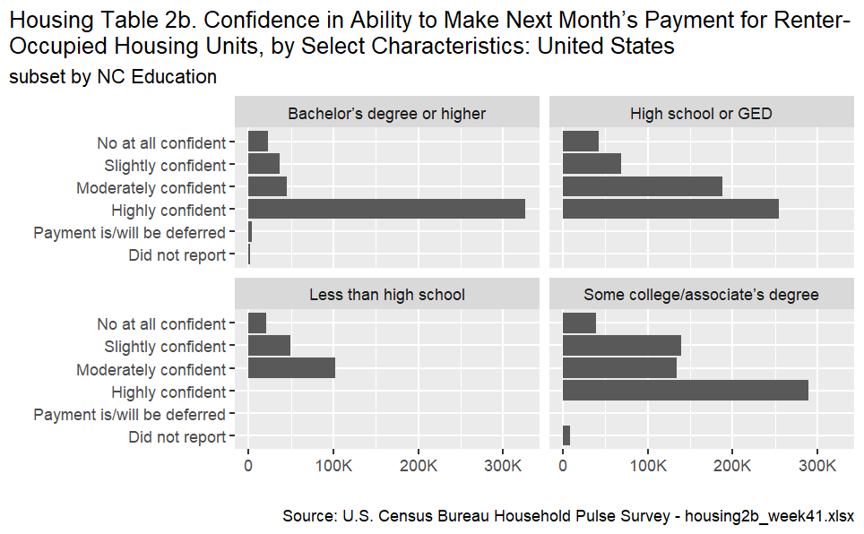

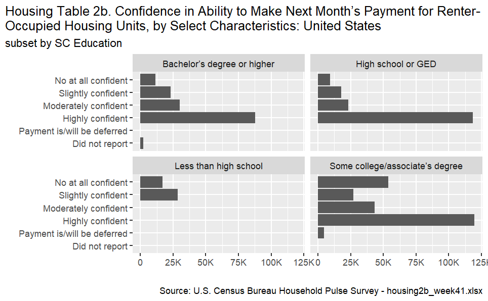

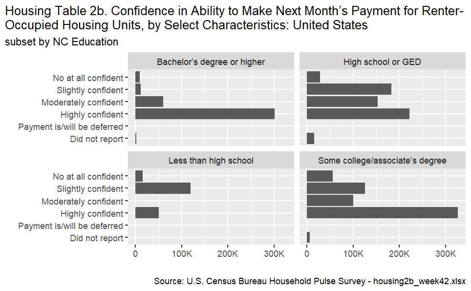

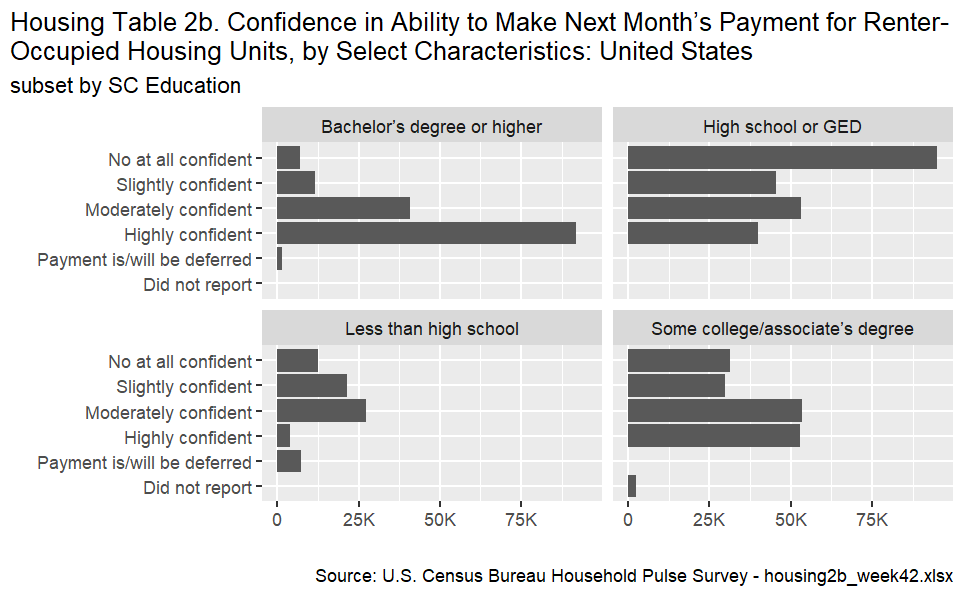

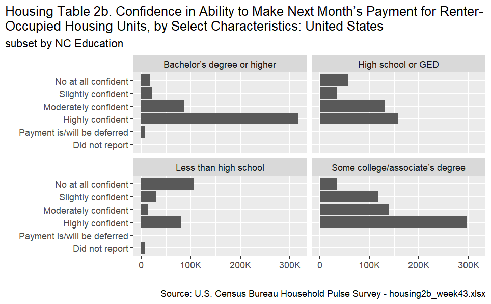

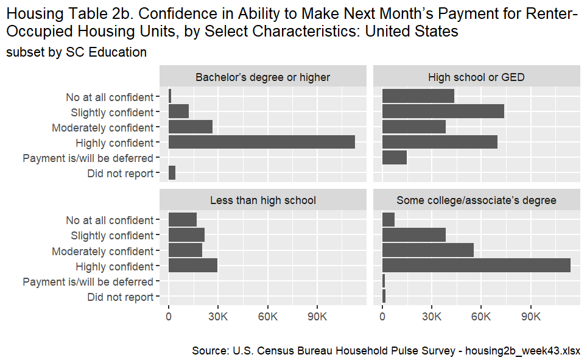

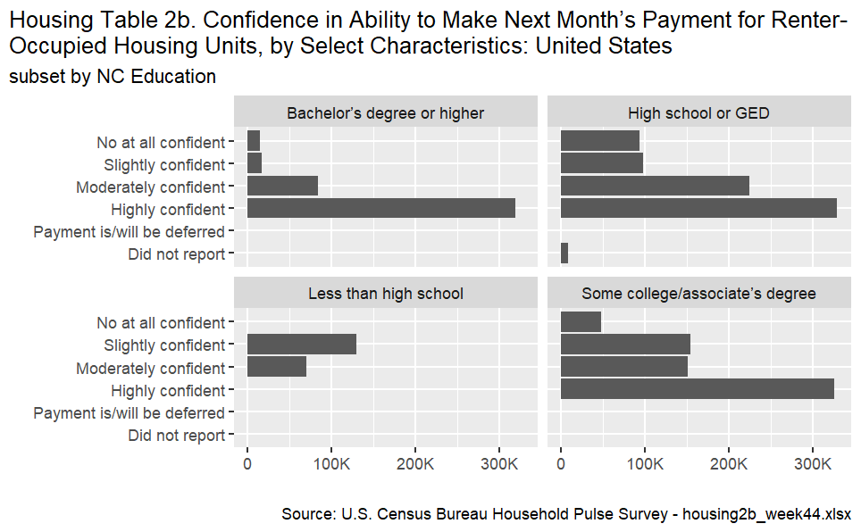

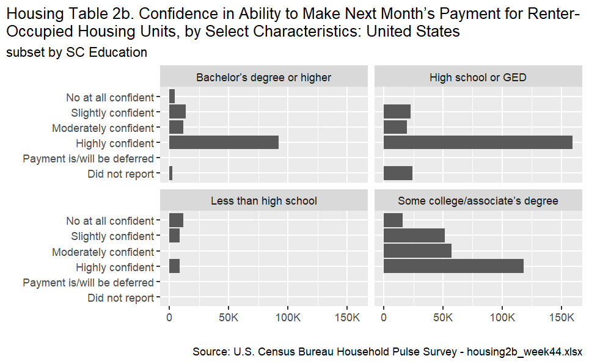

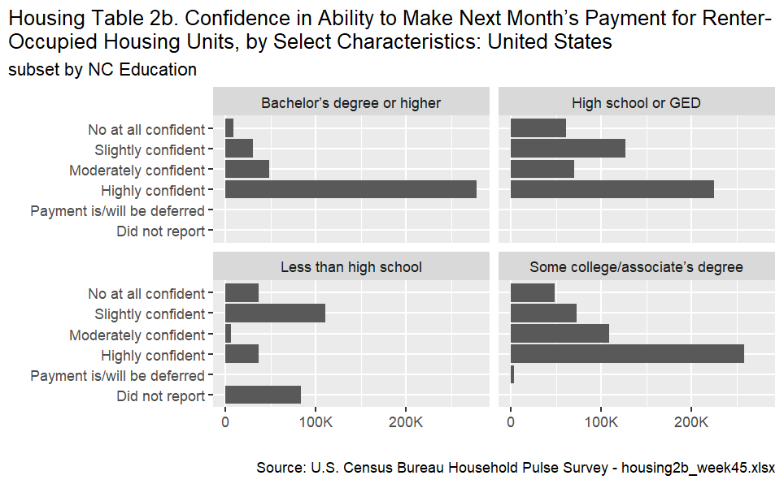

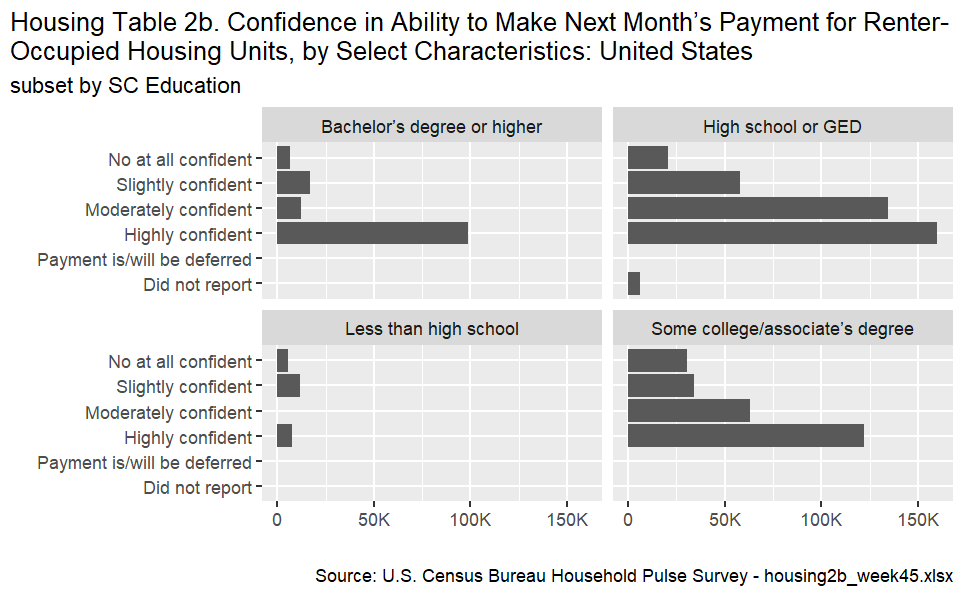

```r
my_df |>
  pull(myplot)
```

## Delete the downloaded files

I wouldn’t normally code to delete a directory, however, it’s done here to keep the size of the repository as small as possible. Since the code-chunk is set to `eval=FALSE`, this code chunk will not run unless you run it manually.

```r
fs::dir_delete("data/xl_workbooks")
fs::dir_delete("output")
```